# LBB Logistic Regression & K-NN

Muh Amri Sidiq

2023-07-19

# Introduction

Machine learning mempunyai beberapa metode untuk memprediksi, saya akan melakukan prediksi terhadap dataset wholesale dengan melihat pengaruh variable baik itu berupa numerik ataupun categorik. Target yang akan digunakan pada prediksi kali ini yaitu Channel. Metode prediksi yang dilakukan akan menggunakan 2 metode yaitu Logistic Regression dan K-NN. Kita akan membandingkan kedua jenis metode dan akan menyimpulkan metode mana yang paling baik untuk digunakan pada prediksi kali ini.

# Library

Sebelum kita memulai kita akan menginstal beberapa library sebagai berikut:

```r
library(tidyverse)
library(caret)
library(plotly)
library(ggplot2)
library(GGally)
library(dplyr)
library(car)
library(class)
library(lmtest)
library(gtools)
```

# Read Data & Data Understanding

## Import Data

Import data yang sudah kita siapkan yaitu wholesale.csv. Gunakan perintah read.csv sesuai dengan extension filenya

```r
wholesale <- read.csv("wholesale.csv")
```

## Data Inspection

Kita lihat sekilas isi datanya dengan perintah Head ()

```r
head(wholesale)
```

|  | Channel | Region | Fresh | Milk | Grocery | Frozen | Detergents_Paper | Delicassen |
| --- | --- | --- | --- | --- | --- | --- | --- | --- |
| 1 | 2 | 3 | 12669 | 9656 | 7561 | 214 | 2674 | 1338 |
| 2 | 2 | 3 | 7057 | 9810 | 9568 | 1762 | 3293 | 1776 |
| 3 | 2 | 3 | 6353 | 8808 | 7684 | 2405 | 3516 | 7844 |
| 4 | 1 | 3 | 13265 | 1196 | 4221 | 6404 | 507 | 1788 |
| 5 | 2 | 3 | 22615 | 5410 | 7198 | 3915 | 1777 | 5185 |
| 6 | 2 | 3 | 9413 | 8259 | 5126 | 666 | 1795 | 1451 |

Kita cek type datanya dengan perintah glimpse ()

```r
glimpse(wholesale)
```

```
#> Rows: 440
#> Columns: 8
#> $ Channel          <int> 2, 2, 2, 1, 2, 2, 2, 2, 1, 2, 2, 2, 2, 2, 2, 1, 2, 1,…
#> $ Region           <int> 3, 3, 3, 3, 3, 3, 3, 3, 3, 3, 3, 3, 3, 3, 3, 3, 3, 3,…
#> $ Fresh            <int> 12669, 7057, 6353, 13265, 22615, 9413, 12126, 7579, 5…
#> $ Milk             <int> 9656, 9810, 8808, 1196, 5410, 8259, 3199, 4956, 3648,…
#> $ Grocery          <int> 7561, 9568, 7684, 4221, 7198, 5126, 6975, 9426, 6192,…
#> $ Frozen           <int> 214, 1762, 2405, 6404, 3915, 666, 480, 1669, 425, 115…
#> $ Detergents_Paper <int> 2674, 3293, 3516, 507, 1777, 1795, 3140, 3321, 1716, …
#> $ Delicassen       <int> 1338, 1776, 7844, 1788, 5185, 1451, 545, 2566, 750, 2…
```

Dari fungsi glimps di atas bisa kita lihat, data memiliki 440 row dan 8 coloumns. Berikut penjelasan mengenai variable nya:

- Channel : Horeca (Hotel/Restaurant/Cafe or Retail channel (Nominal)
- Region : Lisnon, Oporto or Other (Nominal)
- Fresh : annual spending (m.u.) on fresh products (Continuous)
- Milk : annual spending (m.u.) on milk products (Continuous)
- Grocery : annual spending (m.u.)on grocery products (Continuous)
- Frozen : annual spending (m.u.)on frozen products (Continuous)
- Detergents_Paper : annual spending (m.u.) on detergents and paper products (Continuous)
- Delicassen : annual spending (m.u.)on and delicatessen products (Continuous)

## Data Manipulation

Change Type data

```r
wholesale_clean <- wholesale %>%
  mutate(Channel = ifelse(Channel == 1, "Horeca", "Retail")) %>%
  mutate(Channel = as.factor(Channel),
         Region = as.factor(Region))
```

Check Missing values

```r
colSums(is.na(wholesale_clean))
```

```
#>          Channel           Region            Fresh             Milk
#>                0                0                0                0
#>          Grocery           Frozen Detergents_Paper       Delicassen
#>                0                0                0                0
```

# Exploratory Data Analysis

Cek persebaran/pattern data

```r
summary(wholesale_clean)
```

```
#>    Channel    Region      Fresh             Milk          Grocery
#>  Horeca:298   1: 77   Min.   :     3   Min.   :   55   Min.   :    3
#>  Retail:142   2: 47   1st Qu.:  3128   1st Qu.: 1533   1st Qu.: 2153
#>               3:316   Median :  8504   Median : 3627   Median : 4756
#>                       Mean   : 12000   Mean   : 5796   Mean   : 7951
#>                       3rd Qu.: 16934   3rd Qu.: 7190   3rd Qu.:10656
#>                       Max.   :112151   Max.   :73498   Max.   :92780
#>      Frozen        Detergents_Paper    Delicassen
#>  Min.   :   25.0   Min.   :    3.0   Min.   :    3.0
#>  1st Qu.:  742.2   1st Qu.:  256.8   1st Qu.:  408.2
#>  Median : 1526.0   Median :  816.5   Median :  965.5
#>  Mean   : 3071.9   Mean   : 2881.5   Mean   : 1524.9
#>  3rd Qu.: 3554.2   3rd Qu.: 3922.0   3rd Qu.: 1820.2
#>  Max.   :60869.0   Max.   :40827.0   Max.   :47943.0
```

# Logistic Regression

## Cross validation

```r
RNGkind(sample.kind = "Rounding")
set.seed(123)

# index sampling
index <- sample(nrow(wholesale_clean), nrow(wholesale_clean)*0.8)
# splitting
wholesale_train <- wholesale_clean[index,]
wholesale_test <- wholesale_clean[-index,]
```

Cek Proporsi data pada wholesale_train

```r
prop.table(table(wholesale_train$Channel))
```

```
#>
#>    Horeca    Retail
#> 0.6846591 0.3153409
```

Data tidak balance, kita akan melakukan upsampling agar data balance

```r
RNGkind(sample.kind = "Rounding")
set.seed(100)
library(caret)

wholesale_train_up <- upSample(x = wholesale_train %>% select(-Channel),
                       y = wholesale_train$Channel,
                       yname = "Channel")
```

Cek Proporsi data pada wholesale_train_up

```r
prop.table(table(wholesale_train_up$Channel))
```

```
#>
#> Horeca Retail
#>    0.5    0.5
```

## Modeling

Kita akan membuat modeling dengan fungsi glm(), sebagai prediktor adalah semua variable dan targenya adalah channel

```r
model_logistic <- glm(Channel ~ ., wholesale_train_up, family = "binomial")
summary(model_logistic)
```

```
#>
#> Call:
#> glm(formula = Channel ~ ., family = "binomial", data = wholesale_train_up)
#>
#> Coefficients:
#>                     Estimate  Std. Error z value         Pr(>|z|)
#> (Intercept)      -4.13752189  0.65765804  -6.291 0.00000000031482 ***
#> Region2           2.32470217  0.74967925   3.101          0.00193 **
#> Region3           0.70848987  0.55851530   1.269          0.20461
#> Fresh            -0.00001571  0.00001752  -0.897          0.36983
#> Milk              0.00008356  0.00005547   1.506          0.13196
#> Grocery           0.00011132  0.00005450   2.043          0.04110 *
#> Frozen           -0.00005594  0.00004684  -1.194          0.23238
#> Detergents_Paper  0.00095894  0.00013768   6.965 0.00000000000328 ***
#> Delicassen       -0.00012365  0.00011335  -1.091          0.27532
#> ---
#> Signif. codes:  0 '***' 0.001 '**' 0.01 '*' 0.05 '.' 0.1 ' ' 1
#>
#> (Dispersion parameter for binomial family taken to be 1)
#>
#>     Null deviance: 668.19  on 481  degrees of freedom
#> Residual deviance: 216.49  on 473  degrees of freedom
#> AIC: 234.49
#>
#> Number of Fisher Scoring iterations: 8
```

Kita akan melakukan step-wise untuk mencari nilai AIC yang terkecil/ mencari informasi loss yang paming kecil dari model kita

```r
model_step <- step(model_logistic, direction = "backward", trace = F)
summary(model_step)
```

```
#>
#> Call:
#> glm(formula = Channel ~ Region + Grocery + Frozen + Detergents_Paper,
#>     family = "binomial", data = wholesale_train_up)
#>
#> Coefficients:
#>                     Estimate  Std. Error z value           Pr(>|z|)
#> (Intercept)      -4.20701054  0.65137428  -6.459 0.0000000001056282 ***
#> Region2           2.21093277  0.72161499   3.064            0.00218 **
#> Region3           0.64284322  0.55470272   1.159            0.24650
#> Grocery           0.00013960  0.00004278   3.263            0.00110 **
#> Frozen           -0.00007404  0.00004909  -1.508            0.13146
#> Detergents_Paper  0.00097744  0.00012912   7.570 0.0000000000000373 ***
#> ---
#> Signif. codes:  0 '***' 0.001 '**' 0.01 '*' 0.05 '.' 0.1 ' ' 1
#>
#> (Dispersion parameter for binomial family taken to be 1)
#>
#>     Null deviance: 668.19  on 481  degrees of freedom
#> Residual deviance: 220.69  on 476  degrees of freedom
#> AIC: 232.69
#>
#> Number of Fisher Scoring iterations: 8
```

Kita akan memprediksi wholesale_test dengan fungsi predic bedasarkan model_step

## Predict

```r
pred_test_Log <- predict(model_step, type = "response", newdata = wholesale_test)
```

Dari grafik di bawah ini, hasil prediksi dapat di interpretasikan nilainya lebih condong ke arah 0 yaitu horeca

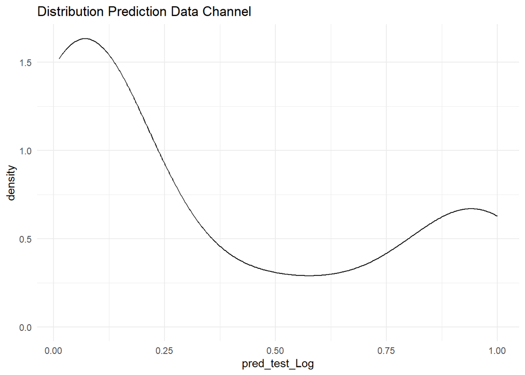

```r
ggplot(wholesale_test, aes(x=pred_test_Log)) +
  geom_density(lwd=0.5) +
  labs(title = "Distribution Prediction Data Channel") +
  theme_minimal()
```

```r
pred_wholesale_test <- ifelse(pred_test_Log > 0.5, "Retail", "Horeca") %>% as.factor()
```

## Model Evaluation

Untuk mengevaluasi model yang telah kita buat, kita akan menggunakan confusion matrix

```r
wholesale_log_con <- confusionMatrix(pred_wholesale_test, wholesale_test$Channel, positive = "Retail")
wholesale_log_con
```

```
#> Confusion Matrix and Statistics
#>
#>           Reference
#> Prediction Horeca Retail
#>     Horeca     54      7
#>     Retail      3     24
#>
#>                Accuracy : 0.8864
#>                  95% CI : (0.8009, 0.9441)
#>     No Information Rate : 0.6477
#>     P-Value [Acc > NIR] : 0.0000003334
#>
#>                   Kappa : 0.7434
#>
#>  Mcnemar's Test P-Value : 0.3428
#>
#>             Sensitivity : 0.7742
#>             Specificity : 0.9474
#>          Pos Pred Value : 0.8889
#>          Neg Pred Value : 0.8852
#>              Prevalence : 0.3523
#>          Detection Rate : 0.2727
#>    Detection Prevalence : 0.3068
#>       Balanced Accuracy : 0.8608
#>
#>        'Positive' Class : Retail
#>
```

- Sensitivity = ukuran kebaikan model terhadap kelas positif
- Specificity = ukuran kebaikan model terhadap kelas negatif
- Accuracy = seberapa tepat model kita memprediksi kelas target (secara global)
- Precision = seberapa presisi model memprediksi kelas positif

```r
Recall <- round(24/(24+7),2)
Specificity <- round((54)/(3+54),2)
Accuracy <- round((54+24)/nrow(wholesale_test),2)
Precision <- round(24/(24+3),2)

performance <- cbind.data.frame(Accuracy, Recall, Precision, Specificity)
performance
```

| Accuracy | Recall | Precision | Specificity |
| --- | --- | --- | --- |
| 0.89 | 0.77 | 0.89 | 0.95 |

## Tuning Cutoff

Digunakan untuk mengetahui threshold maksimum dari apa yang akan kita teliti.

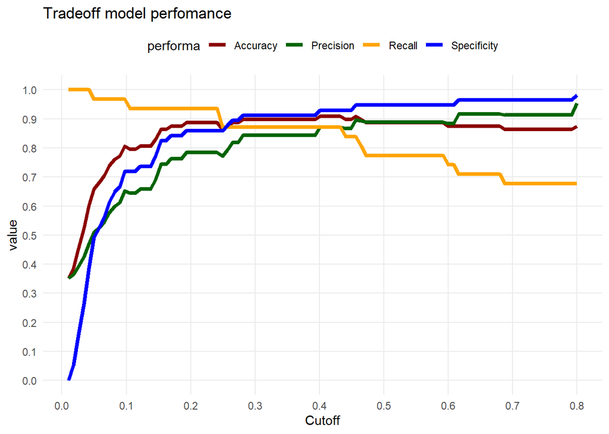

```r
performa <- function(cutoff, prob, ref, postarget, negtarget)
{
  predict <- factor(ifelse(prob >= cutoff, postarget, negtarget))
  conf <- caret::confusionMatrix(predict , ref, positive = postarget)
  acc <- conf$overall[1]
  rec <- conf$byClass[1]
  prec <- conf$byClass[3]
  spec <- conf$byClass[2]
  mat <- t(as.matrix(c(rec , acc , prec, spec)))
  colnames(mat) <- c("recall", "accuracy", "precicion", "specificity")
  return(mat)
}

co <- seq(0.01,0.80,length=100)
result <- matrix(0,100,4)

for(i in 1:100){
  result[i,] = performa(cutoff = co[i],
                     prob = pred_test_Log,
                     ref = wholesale_test$Channel,
                     postarget = "Retail",
                     negtarget = "Horeca")
}

data_frame("Recall" = result[,1],
           "Accuracy" = result[,2],
           "Precision" = result[,3],
           "Specificity" = result[,4],
                   "Cutoff" = co) %>%
  gather(key = "performa", value = "value", 1:4) %>%
  ggplot(aes(x = Cutoff, y = value, col = performa)) +
  geom_line(lwd = 1.5) +
  scale_color_manual(values = c("darkred","darkgreen","orange", "blue")) +
  scale_y_continuous(breaks = seq(0,1,0.1), limits = c(0,1)) +
  scale_x_continuous(breaks = seq(0,1,0.1)) +
  labs(title = "Tradeoff model perfomance") +
  theme_minimal() +
  theme(legend.position = "top",
        panel.grid.minor.y = element_blank(),
        panel.grid.minor.x = element_blank())
```

Berdasarkan Tradeoff model performance diatas, dapat kita tahu bahwa dengan cutoff 0.5 kita memperoleh nilai specifity, accuracy dan precision lebih tingggi, namun nilai recall agak rendah.

## Model Interpretation

```r
# Odds ratio all coefficients
exp(model_step$coefficients) %>%
  data.frame()
```

|  | . |
| --- | --- |
| (Intercept) | 0.01489082 |
| Region2 | 9.12422326 |
| Region3 | 1.90188066 |
| Grocery | 1.00013961 |
| Frozen | 0.99992596 |
| Detergents_Paper | 1.00097792 |

# K-NN

Kita akan menggunakan data sebelumnya dengan menggunakan machine learning type K-NN

## Read Data

```r
head(wholesale_clean)
```

|  | Channel | Region | Fresh | Milk | Grocery | Frozen | Detergents_Paper | Delicassen |
| --- | --- | --- | --- | --- | --- | --- | --- | --- |
| 1 | Retail | 3 | 12669 | 9656 | 7561 | 214 | 2674 | 1338 |
| 2 | Retail | 3 | 7057 | 9810 | 9568 | 1762 | 3293 | 1776 |
| 3 | Retail | 3 | 6353 | 8808 | 7684 | 2405 | 3516 | 7844 |
| 4 | Horeca | 3 | 13265 | 1196 | 4221 | 6404 | 507 | 1788 |
| 5 | Retail | 3 | 22615 | 5410 | 7198 | 3915 | 1777 | 5185 |
| 6 | Retail | 3 | 9413 | 8259 | 5126 | 666 | 1795 | 1451 |

## Data Wrangling

Cek type data

```r
glimpse(wholesale_clean)
```

```
#> Rows: 440
#> Columns: 8
#> $ Channel          <fct> Retail, Retail, Retail, Horeca, Retail, Retail, Retai…
#> $ Region           <fct> 3, 3, 3, 3, 3, 3, 3, 3, 3, 3, 3, 3, 3, 3, 3, 3, 3, 3,…
#> $ Fresh            <int> 12669, 7057, 6353, 13265, 22615, 9413, 12126, 7579, 5…
#> $ Milk             <int> 9656, 9810, 8808, 1196, 5410, 8259, 3199, 4956, 3648,…
#> $ Grocery          <int> 7561, 9568, 7684, 4221, 7198, 5126, 6975, 9426, 6192,…
#> $ Frozen           <int> 214, 1762, 2405, 6404, 3915, 666, 480, 1669, 425, 115…
#> $ Detergents_Paper <int> 2674, 3293, 3516, 507, 1777, 1795, 3140, 3321, 1716, …
#> $ Delicassen       <int> 1338, 1776, 7844, 1788, 5185, 1451, 545, 2566, 750, 2…
```

Kita hanya akan menggunakan data type numerik sebagai prediktor

```r
wholesale_knn <- wholesale_clean %>% select(-Region)
```

## Exploratory Data Analysis

Cek proporsi Kelas

```r
prop.table(table(wholesale_knn$Channel))
```

```
#>
#>    Horeca    Retail
#> 0.6772727 0.3227273
```

## Cross Validation

```r
RNGkind(sample.kind = "Rounding")
set.seed(123)

# index sampling
index <- sample(nrow(wholesale_knn), nrow(wholesale_knn)*0.8)
# splitting
wholesale_knn_train <- wholesale_knn[index,]
wholesale_knn_test <- wholesale_knn[-index,] # data yang tidak masuk train
```

Cek Proporsi data pada wholesale_knn_train

```r
prop.table(table(wholesale_knn_train$Channel))
```

```
#>
#>    Horeca    Retail
#> 0.6846591 0.3153409
```

Data tidak balance kita akan melakukan upsampling

```r
RNGkind(sample.kind = "Rounding")
set.seed(100)
library(caret)

wholesale_knn_train_up <- upSample(x = wholesale_knn_train %>% select(-Channel),
                       y = wholesale_knn_train$Channel,
                       yname = "Channel")
```

Cek Proporsi data pada wholesale_train_up

```r
prop.table(table(wholesale_knn_train_up$Channel))
```

```
#>
#> Horeca Retail
#>    0.5    0.5
```

## Data Pre-Processing

Untuk k-NN, dipisahkan antara prediktor dan label (target variabelnya).

```r
# prediktor data train
wholesale_knn_train_x <- wholesale_knn_train_up %>% select_if(is.numeric)

# target data train
wholesale_knn_train_y <- wholesale_knn_train_up[,"Channel"]

# prediktor data test
wholesale_knn_test_x <- wholesale_knn_test %>% select_if(is.numeric)

# target data test
wholesale_knn_test_y <- wholesale_knn_test[,"Channel"]
```

Tahap selanjutnya kita akan melakukan scaling di data train

```r
# scaling data
# train
wholesale_knn_train_xs <- scale(x = wholesale_knn_train_x) # data prediktor untuk data train

# test
wholesale_knn_test_xs <- scale(x = wholesale_knn_test_x,
                      center = attr(wholesale_knn_train_xs, "scaled:center"), #nilai rata rata data
                      scale = attr(wholesale_knn_train_xs,"scaled:scale")) # nilai data train
```

Menentukan nilai K dengan rumus di bawah ini

```r
sqrt(nrow(wholesale_knn_train))
```

```
#> [1] 18.76166
```

K Optimum = 19

```r
library(class)
pred_knn_wholsesale <- knn(train = wholesale_knn_train_xs, # prediktor data train
                test = wholesale_knn_test_xs, # prediktor data test
                cl = wholesale_knn_train_y, # label dari data train
                k = 19)
head(pred_knn_wholsesale)
```

```
#> [1] Retail Horeca Retail Retail Retail Retail
#> Levels: Horeca Retail
```

## Model evaluation

```r
# confusion matrix
library(caret)
wholesale_knn_conf <- confusionMatrix(pred_knn_wholsesale, wholesale_knn_test_y, positive = "Retail")
wholesale_knn_conf
```

```
#> Confusion Matrix and Statistics
#>
#>           Reference
#> Prediction Horeca Retail
#>     Horeca     53      4
#>     Retail      4     27
#>
#>                Accuracy : 0.9091
#>                  95% CI : (0.8287, 0.9599)
#>     No Information Rate : 0.6477
#>     P-Value [Acc > NIR] : 0.00000001509
#>
#>                   Kappa : 0.8008
#>
#>  Mcnemar's Test P-Value : 1
#>
#>             Sensitivity : 0.8710
#>             Specificity : 0.9298
#>          Pos Pred Value : 0.8710
#>          Neg Pred Value : 0.9298
#>              Prevalence : 0.3523
#>          Detection Rate : 0.3068
#>    Detection Prevalence : 0.3523
#>       Balanced Accuracy : 0.9004
#>
#>        'Positive' Class : Retail
#>
```

# Model Evaluation Logistic Regression and K-NN

```r
eval_wholesale_log <- data_frame(Accuracy = wholesale_log_con$overall[1],
                                 Recall = wholesale_log_con$byClass[1],
                                 Specificity = wholesale_log_con$byClass[2],
                                 Precision = wholesale_log_con$byClass[3])

eval_wholesale_knn <- data_frame(Accuracy = wholesale_knn_conf$overall[1],
                                 Recall = wholesale_knn_conf$byClass[1],
                                 Specificity = wholesale_knn_conf$byClass[2],
                                 Precision = wholesale_knn_conf$byClass[3])
```

```r
# Model Evaluation Logistic Regretion
eval_wholesale_log
```

| Accuracy | Recall | Specificity | Precision |
| --- | --- | --- | --- |
| 0.8863636 | 0.7741935 | 0.9473684 | 0.8888889 |

```r
# Model Evaluation K-NN
eval_wholesale_knn
```

| Accuracy | Recall | Specificity | Precision |
| --- | --- | --- | --- |
| 0.9090909 | 0.8709677 | 0.9298246 | 0.8709677 |

Jika dilihat dari kedua metode tersebut, yaitu dengan menggunakan Regresi Logistik dan K-NN, seberapa mampu proporsi model saya menebak benar Channel yang Retail lebih baik dengan menggunakan metode K-NN karena memiliki nilai Recall= 87,1% lebih besar dari pada menggunakan metode regresi logistik.

# Conclusion